# 03_Models-Copy1.fixed

## 2.4. The Bottom Line

In this section we will display the macro-averaged F1-scores of the best models in tabular form and create a picture to display all the confunsion matrices (given the best models).

```python
# We create a function similar to the older one to create CM
def plot_cm_multiaxes(y_test, Y_pred, labels = None, ann_size = 12, cbar_fontsize = 12, x_ticklabel_size = 12, y_ticklabel_size = 12, **kwargs):

  """
  Function plots confusion matrices in a single canvas.
  Arguments:
    - y_test: pandas series (or numpy vector) containing the true labels.
    - Y_pred: a pandas dataframe containing the predictions
    - Labels: the labels to be used in the plot.
    - ann_size: the size of the annotation-font.
    - cbar_fontsize: the size of the font used in the bar in the right side of the graph.
    - x_ticklabel_size: size of the font used to label the x-axis
    - y_ticklabel_size: size of the font used to label the y-axis
    - kwargs:
      - titles: a list of titles to pass to the plots. If not passed, the titles will be "Confunion Matrix:" followed by the names of the columns in the Y_pred dataset.
      - figsize: a tuple with the dimensions of the canvas for the plot
      - sharex: a boolean specifying whether the X axis should be shared
      - sharey: a boolean specifying whether the y axis should be shared
  """

  # get the number of columns in the Y_pred dataset, it will be the same number of axes we need
  axes_num = Y_pred.shape[1]

  default_titles = ['Confusion Matrix: ' + str(column) for column in Y_pred.columns.tolist()]
  titles = kwargs.get('titles', default_titles)
  default_figsize = (4, 4)
  figsize = kwargs.get('figsize', default_figsize)
  sharex = kwargs.get('sharex', True)
  sharey = kwargs.get('sharey', True)
  # make sure that figsize was passed as a tuple
  assert isinstance(figsize, tuple), 'figsize must be passed as a tuple containing the width and the height: (width, height)'
  #get unique labels
  num_labels = unique_labels(y_test)

  if labels != None:
      assert isinstance(labels, dict), 'Labels need to be passed as a dictionary mapping numbers to representations'
      try:

          labels = [labels[i] for i in num_labels]
      except:
          labels = [labels[str(i)] for i in num_labels]
  else:
      labels = num_labels

  # create a dictionary to store the confusion matrices
  confusion_matrices = {}
  # now iterate over the columns of the dataset with the predictions and compute the confusion matrices
  for column in Y_pred.columns.tolist():

    confusion_matrices[column] = metrics.confusion_matrix(y_test, Y_pred[column].tolist(), labels = num_labels)

  # in the figure, a row will have two axes, so the number of rows we need will be the number of axes divided by 2 (rounded up in the case of uneven number)
  n_rows = math.ceil(axes_num / 2)
  n_cols = 2 if n_rows > 1 else 1

  # create the subplots
  fig, axes = plt.subplots(n_rows, n_cols, figsize = figsize, sharex = sharex, sharey = sharey)

  # Now we check whether we fill in all axes or if there is an axis without data. In this case, we make this axis (the last one) invisible
  if axes_num % 2 > 0 and n_rows > 1:
    axes[-1, -1].set_visible(False)

  # we now iterate over the axis and plot the results
  counter = 0
  for i, ax_row in enumerate(axes):

    for j, ax in enumerate(ax_row):

      # we create an exception, because if we have more axis than data, it will cause an error when we try to plot the last graph
      try:

        cm_name = list(confusion_matrices)[counter]

        heatmap = sns.heatmap(
            confusion_matrices[cm_name],
            annot = True,
            fmt = 'd',
            cmap = 'Blues',
            xticklabels = labels,
            yticklabels = labels,
            ax = ax,
            annot_kws = {'size': ann_size}
        )
        cbar = heatmap.collections[0].colorbar
        cbar.ax.tick_params(labelsize=cbar_fontsize)

        if j == 0:
          ax.set_ylabel('True label', labelpad = 20, fontsize = y_ticklabel_size)
        if i == (len(axes) - 1):
          ax.set_xlabel('Predicted', labelpad = 20, fontsize = x_ticklabel_size)
        ax.set_title(titles[counter], pad = 5, weight = 'bold')
        counter += 1
      except:
        pass
  return fig, axes
```

We will now import the best XGBoost and SVM models.

```python
import pickle
model_paths = ['Models_Ch2_XGB_Raw_ParameterSet2.pkl', 'Models_Ch2_SVM_Raw_ParameterSet2.pkl']
model_names = ['XGB', 'SVM']

ML_models = {}

for i, model_path in enumerate(model_paths):
  with open(models_dir + model_path, 'rb') as model:
    ML_models[model_names[i]] = pickle.load(model)
```

we load the financial phrasebank dataset and split it again. We use the test set to make predictions (notice that this is a repetition of that what we've done so far. This sections is intended to bring all the results in a single plot)

```python
# load the finanical phrase dataset again and split the data using the same random seed as before
file_name = 'Models_Ch1_finPB.csv'
df_finPB = pd.read_csv(driver_path + file_name)


X = df_finPB['sentence']
y = df_finPB['label']

random_seed = int(str(datetime(1992, 11, 23).timestamp())[:3]) # I will get the first three values which are (722)
X_train, X_test, y_train, y_test = train_test_split(X, y, stratify=y, random_state=random_seed, test_size = 0.2)
```

We create a pandas dataframe to store the predictions of all (best) models. In order to format the data as needed to pass to the function defined above.

```python
Y_pred = pd.DataFrame()

# Machine learning models
Y_pred['XGBoost'] = ML_models['XGB'].best_estimator_.predict(X_test)
Y_pred['SVM'] = ML_models['SVM'].best_estimator_.predict(X_test)

# dictionary
LM = pysentiment2.LM()
# use the default tokenizer to process the phrases
X_LM['tokens'] = X_test.apply(lambda x: LM.tokenize(x))
y_LM = X_LM['tokens'].apply(lambda x: LM.get_score(x)) # make sure to run the code with the function in Section 2.1.
Y_pred['LM-Dictionary'] = y_LM.apply(assign_classLM, lb = -0.5, ub = 0.5).tolist()
# finBert
nlp = pipeline('sentiment-analysis', model = finBert, tokenizer = tokenizer, device = 'cuda') # make sure to have downloaded the model as in section 2.3
pred = pd.DataFrame()
pred['raw_text'] = nlp(X_test.to_list())
Y_pred['finBert'] = pred['raw_text'].apply(lambda x: 0 if x['label'] == 'Negative' else 1 if x['label'] == 'Neutral' else 2)
```

Now that we have all the data we need, we will save the dataset with the predictions and plot the confunsion matrices.

```python
# save dataset
file_name = 'Models_Ch2_TestSet_Predictions.csv'
#Y_pred.to_csv(driver_path + file_name, index = True)
# load the dataset gain
Y_pred = pd.read_csv(tables_dir + file_name, index_col = 'Unnamed: 0')
#Y_pred.head(5)
```

We will compute the macro averaged F1-score out of this data

```python
scores = {}
for column in Y_pred.columns.tolist():
  scores[column] = f1_score(y_test, Y_pred[column].tolist(), average = 'macro')
scores = pd.DataFrame(data = scores, index = ['F1-score'])
```

Models Performance (Macro-avg. F1-score)

Tab. 2.8: *The table displays the macro-averaged F1-score of the models computed with the best-parameters as shown in past sections. To compute the performances the same test set was used for all models. finBert shows the best performance with a macro-F1 score of 0.773, followed by SVM with with a score of 0.733 and XGBoost with a score of 0.718. As expected the approach using the LM-dictionary performed worse than all other models.*

|  | XGBoost | SVM | LM-Dictionary | finBert |
| --- | --- | --- | --- | --- |
| F1-score | 0.718285 | 0.733405 | 0.462609 | 0.772686 |

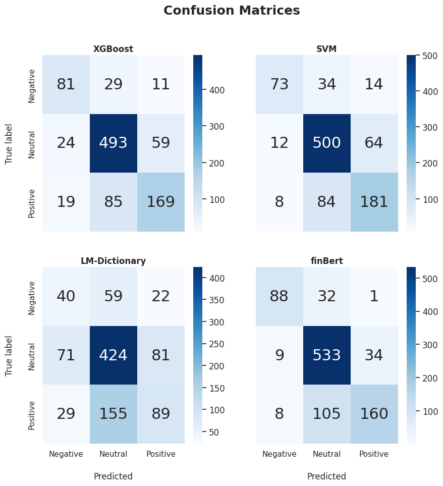

```python
fig, axes = plot_cm_multiaxes(y_test, Y_pred, labels = {'0': 'Negative', '1': 'Neutral', '2': 'Positive'},
                              figsize = (10, 10),
                              titles = ['XGBoost', 'SVM', 'LM-Dictionary', 'finBert'],
                              ann_size = 22)
creator.tabDesc(
    title = 'Models Performance (Macro-avg. F1-score)',
    caption = 'The table displays the macro-averaged F1-score of the models computed with the best-parameters as shown in past sections. To compute'\
    + ' the performances the same test set was used for all models. finBert shows the best performance with a macro-F1 score of 0.773, followed by SVM with'\
    + ' with a score of 0.733 and XGBoost with a score of 0.718. As expected the approach using the LM-dictionary performed worse than all other models.',
    cap_style = 'font-size:13px; text-align:justify;',
    type = 'Tab.',
    type_num = '2.8',
    disp = True
)
display(HTML(scores.to_html()))
# We pass a suptitle to the plot
fig_name = 'Models_Ch2_CMatrices.png'
fig.suptitle('Confusion Matrices', fontweight = 'bold', fontsize = 18);
#fig.savefig(driver_path + fig_name, bbox_inches = 'tight')
```